# Chapter 6

onyambu

10/8/2020

```python
import numpy as np
import matplotlib.pyplot as plt
from scipy import stats
```

# 6.2.17

A likelihood function is given by $\exp \left(-(\theta-1)^{2} / 2\right)+3 \exp \left(-(\theta-2)^{2} / 2\right)$ for $\theta \in R^{1}$. Numerically approximate the MLE by evaluating this function at 1000 equispaced points in (-10,10] . Also plot the likelihood function.

Solution: Check the Jupyter Notebook for more clarification.

## R

```r
L <- function(theta) exp(-(theta-1)^2/2) + 3*exp(-(theta-2)^2/2)
x <- seq(-10, 10, length.out = 1000)
y <- L(x)
MLE <- x[which.max(y)]
MLE
```

```
## [1] 1.811812
```

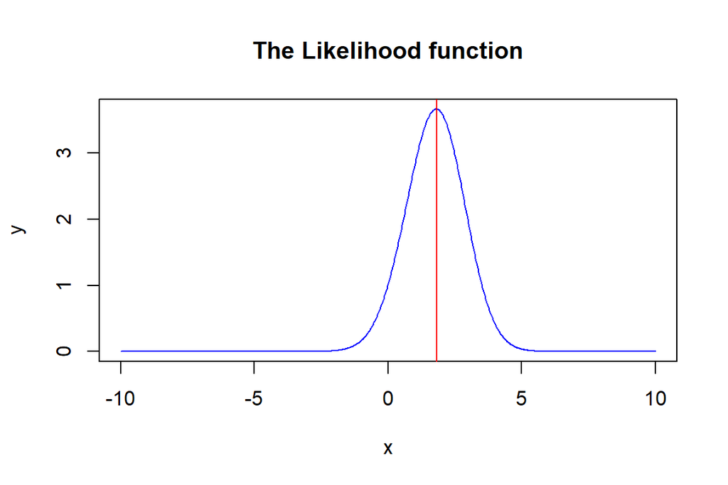

```r
plot(x,y, main="The Likelihood function", ty="l", col="blue")
abline(v=MLE, col="red")
```

## Python

I will use `lambda` keyword instead of `def` keyword in creating short functions in python. Check the Python Notebook on how to use the `def` keyword

```python
L = lambda theta: np.exp(-(theta-1)**2/2) + 3*np.exp(-(theta-2)**2/2)
x = np.linspace(-10, 10, 1000)
y = L(x)
MLE = x[y.argmax()]
MLE
```

```
## 1.8118118118118112
```

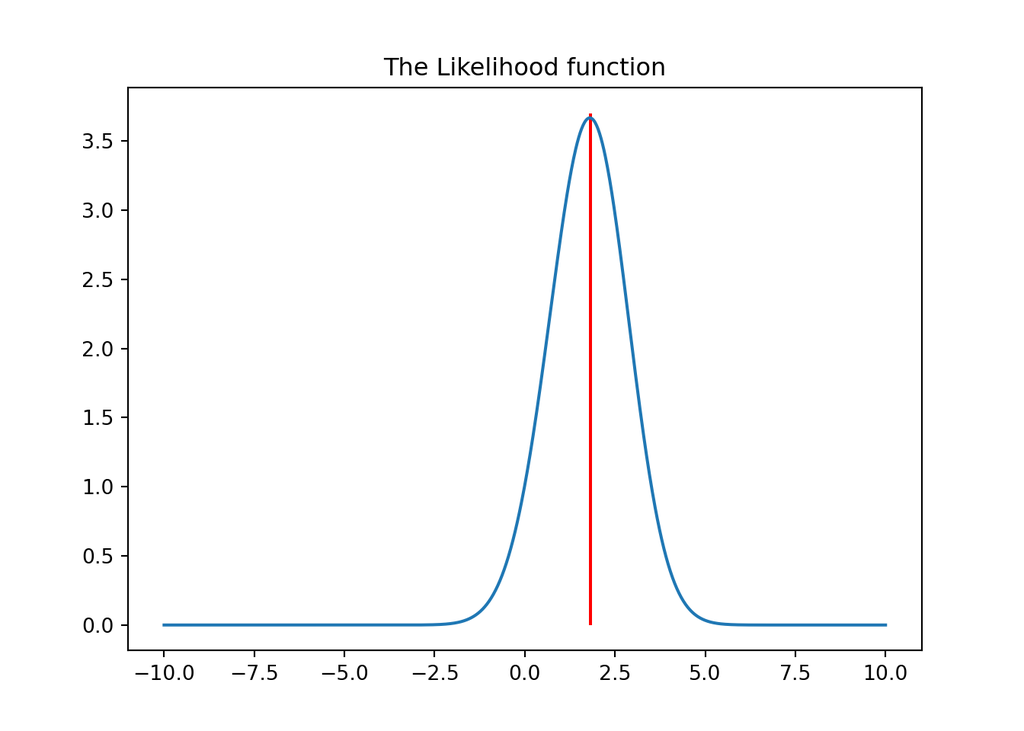

```python
a = plt.plot(x, y)
plt.title('The Likelihood function')
plt.vlines(MLE,0,3.7, colors="red")
```

# 6.2.25

Suppose the proportion of left-handed individuals in a population is $\theta .$ Based on a simple random sample of $20$ you observe four left-handed individuals.

## (a)

Assuming the sample size is small relative to the population size, plot the loglikelihood function and determine the MLE.

## R

Soln: Since the population size is large relative to the sample, the r.v thus follows a binomial distribution with n = 20, p=$\theta$. since we are given that x=4, we can be able to obtain the MLE OF of $\theta$ ie $\hat\theta = 4/20=0.2$.

Using Binomial distribution:

```r
p <- seq(0, 1,length.out = 101)
y_bin <- dbinom(4, 20, p)
MLE <- p[which.max(y_bin)]
MLE
```

```
## [1] 0.2
```

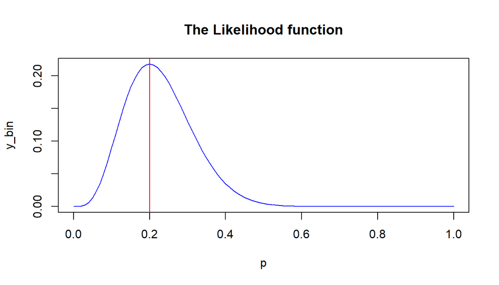

```r
plot(p, y_bin, ty="l", main = "The Likelihood function", col="blue")
abline(v=MLE, col="red")
```

We could also use the hypergeometric distribution:

```r
n <- length(p) - 1
y_hyp <- dhyper(4, p*n, (1-p) * n, 20)
MLE <- p[which.max(y_hyp)]
MLE
```

```
## [1] 0.2
```

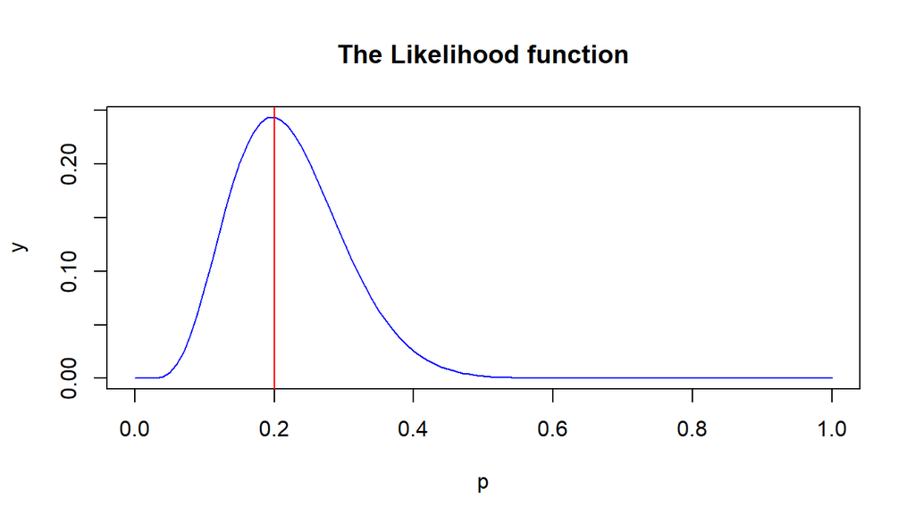

```r
plot(p,y_hyp, ty="l", main = "The Likelihood function", ylab = "y", col="blue")
abline(v=MLE, col="red")
```

In both cases, the results are exactly the same. Just to point out, when the population is relatively large, we use binomial distribution. It is computationaly intensive to use hypergeometric.

## Python

```python
p = np.linspace(0, 1, 101)
y_bin = stats.binom(n = 20, p = p).pmf(4)
MLE = p[y_bin.argmax()]
MLE
```

```
## 0.2
```

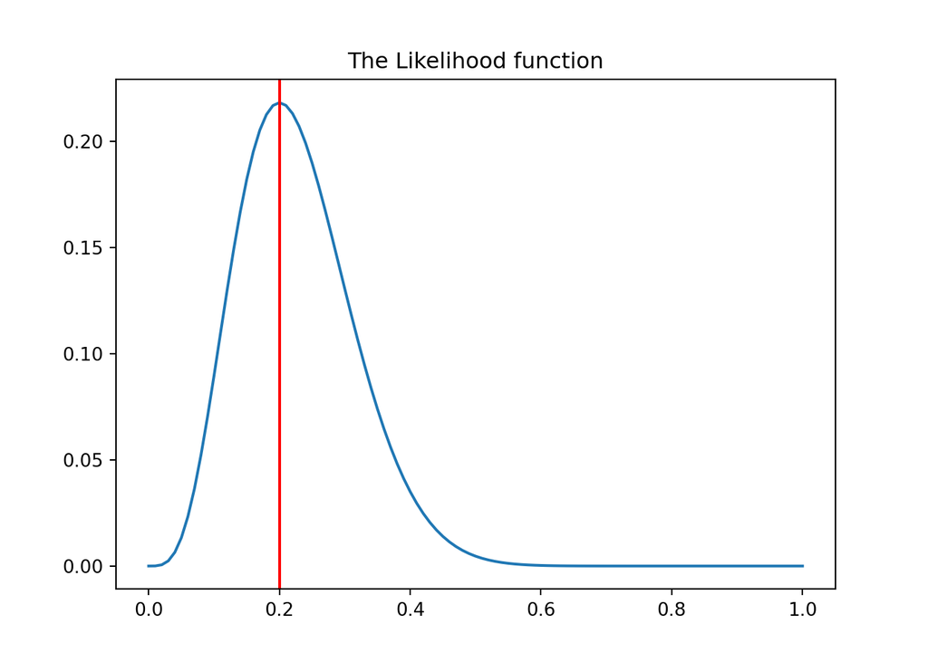

```python
a=plt.plot(p, y_bin)
plt.title("The Likelihood function")
plt.axvline(MLE, color="red")
```

```python
p = np.linspace(0, 1, 101)
y_hyp = stats.hypergeom(p.size, p * p.size, 20).pmf(4)
MLE = p[y_hyp.argmax()]
MLE
```

```
## 0.2
```

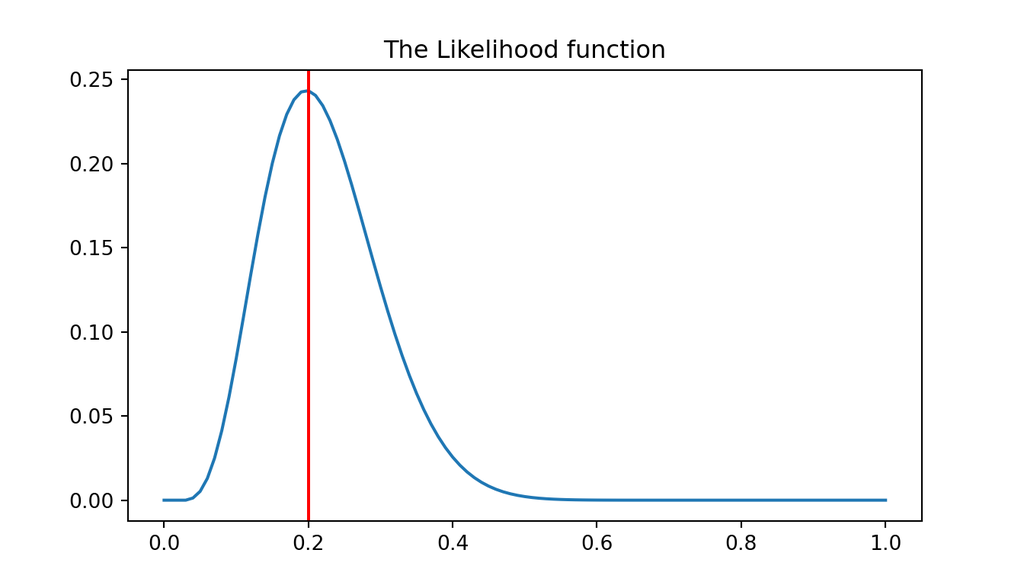

```python
a=plt.plot(p,y_hyp)
plt.title("The Likelihood function")
plt.axvline(MLE, color="red")
```

## (b)

If instead the population size is only $50,$ then plot the log-likelihood function and determine the MLE. (Hint: Remember that the number of left-handed individuals follows a hypergeometric distribution. This forces $\theta$ to be of the form $i / 50$ for some integer $i$ between 4 and $34 .$ From a tabulation of the log-likelihood, you can obtain the MLE.)

# 6.3.19

Suppose a measurement on a population can be assumed to follow the $N\left(\mu, \sigma^{2}\right)$ distribution, where $\left(\mu, \sigma^{2}\right) \in R^{1} \times(0, \infty)$ is unknown and the size of the population is very large. A very conservative upper bound on $\sigma$ is given by $5 .$ A researcher wants to determine a 0.95 -confidence interval for $\mu$ that is no longer than $1 .$ Determine a sample size that will guarantee this. (Hint: Start with a large sample approximation.)

Soln:

$$n \geq b^{2}\left(\frac{t_{(1+\gamma) / 2}(n-1)}{\delta}\right)^{2}$$

R

```r
fn <- function(n)5^2 * qt((1+0.95)/2, n-1)^2
fn(1000000) # a very large number
```

```
## [1] 96.0367
```

# 6.3.22

Generate $10^{4}$ samples of size $n=5$ from the $N(0,1)$ distribution. For each of these samples, calculate the interval $(\bar{x}-s / \sqrt{5}, \bar{x}+s / \sqrt{5}),$ where $s$ is the sample standard deviation, and compute the proportion of times this interval contains $\mu .$ Repeat this simulation with $n=10$ and 100 and compare your results.

TRUE RESULTS: $P\left(\bar{x}-\frac{s}{\sqrt{n}}\le \mu\le \bar{x}+\frac{s}{\sqrt{n}}\right) = 0.6826895$

```r
pnorm(1) - pnorm(-1)
```

```
## [1] 0.6826895
```

## R

```r
conf_Interval <- function(n){
  x <- rnorm(n)
  margin <- sd(x)/sqrt(n)
  mean(x) + c(-margin, margin)
}

Intervals_5 <- replicate(10^4, conf_Interval(5))
mean(Intervals_5[1,]<0 &Intervals_5[2,]>0)
```

```
## [1] 0.6272
```

```r
Intervals_10 <- replicate(10^4, conf_Interval(10))
mean(Intervals_10[1,]<0 &Intervals_10[2,]>0)
```

```
## [1] 0.6637
```

```r
Intervals_100 <- replicate(10^4, conf_Interval(100))
mean(Intervals_100[1,]<0 &Intervals_100[2,]>0)
```

```
## [1] 0.6751
```

## Python

```python
def conf_Interval(n):
  x = np.random.normal(size=n)
  margin = x.std()/np.sqrt(n)
  return np.mean(x) + np.r_[-margin, margin]

Intervals_5 = np.array([conf_Interval(5) for i in range(10**4)])
np.mean((Intervals_5[:,0]<0) & (Intervals_5[:,1]>0))
```

```
## 0.5734
```

```python
Intervals_10 = np.array([conf_Interval(10) for i in range(10**4)])
((Intervals_10[:, 0]<0) & (Intervals_10[:,1]>0)).mean()
```

```
## 0.6333
```

```python
Intervals_100 = np.array([conf_Interval(100) for i in range(10**4)])
((Intervals_100[:,0]<0) & (Intervals_100[:,1]>0)).mean()
```

```
## 0.6766
```

#6.4.1

Suppose we ohtained the following sample from a distrihution that we know has its first six moments. Determine an approximate 0.95-confidence interval for $\mu_{3}$.

Soln: Note that

$$m_{i} \pm z_{(1+\gamma) / 2} \frac{s_{i}}{\sqrt{n}}$$
where

$$s_{i}^{2}=\frac{1}{n-1} \sum_{j=1}^{n}\left(x_{j}^{i}-m_{i}\right)^{2}$$
and

$$m_{i}=\frac{1}{n} \sum_{j=1}^{n} x_{j}^{i}$$

## R

```r
x <- c(3.27, -1.24, 3.97, 2.25, 3.47, -0.09, 7.45, 6.2, 3.74, 4.12,
1.42, 2.75, -1.48, 4.97, 8, 3.26, 0.15, -3.64, 4.88, 4.55)
margin <- qnorm((1 + 0.95)/2) * sd(x ** 3)/sqrt(length(x))
mean(x ** 3) + c(lower = -margin, upper = margin)
```

```
##     lower     upper
##  26.07684 151.41164
```

## Python

```python
x = np.r_[3.27, -1.24, 3.97, 2.25, 3.47, -0.09, 7.45, 6.2, 3.74, 4.12,
1.42, 2.75, -1.48, 4.97, 8, 3.26, 0.15, -3.64, 4.88, 4.55]
margin = stats.norm().ppf((1 + 0.95)/2) * (x**3).std()/np.sqrt(x.size)
np.mean(x**3) + np.r_[-margin, margin]
```

```
## array([ 27.66361255, 149.82487005])
```

# 6.4.17

For the data of Exercise $6.4.1,$ use the plug-in MLE to estimate $F(3)$ for an $N\left(\mu, \sigma^{2}\right)$ distribution. Use bootstrapping to estimate the MSE of this estimate for $m=10^{3}$ and $m=10^{4}$

## Estimating F(3)

### R

```r
(F3_estimate <- pnorm(3, mean(x), sd(x)))
```

```
## [1] 0.5133075
```

### Python

```python
F3_estimate = stats.norm(x.mean(), x.std()).cdf(3)
F3_estimate
```

```
## 0.5136530876576368
```

## Bootstrap MSE estimate:

### R

```r
sample_proportion <- mean(x <= 3)
bias_sq <- (F3_estimate -sample_proportion)**2

bootstrap <- function(){
  x_sample <- sample(x, replace = TRUE)
  pnorm(3, mean(x_sample), sd(x_sample))
}

var(replicate(10**3, bootstrap())) + bias_sq
```

```
## [1] 0.02105879
```